# ST661 Project

Group 4

## Dataset: Tour de France

### Introduction

The data files we worked with contain real life information from the annual bicycle race, The Tour de France. Riders from all over the world participate in the event. The Tour de France is a multiple stage race which takes place over several days. Usually, the race is held in France but occasionally a stage or indeed the entire event is held in another country. The Tour de France began in 1903, and the initial years consisted mostly of French riders or their close neighbours. Sports science, bicycle technology and indeed pharmaceuticals have evolved over the years. Also testing and standardization have been introduced. The data we were presented with consisted of three files, two of which focus on stage data and one on winner’s data. There are many analysis opportunities with this data, for the purpose of this project we have chosen to focus on how athletes’ performance is affected by personal attributes such as physicality, age, and country of birth, the data of which is obtained from the “tdf_winners” data file. Our report explores the following questions:

1. Does an athlete’s country of birth affect their results?

We check if the athlete’s country of birth has any effect on the results of the competition. Will traits such as adapting to atmospheric pressure and the prevailing climate in Western Europe affect performance. Do you have an advantage over other riders if you are from the country the race is held in?

2. Does an athlete’s BMI influence their speed?

We test how fitness affects competition results. Is there a relationship between health and winning the trophy? We look for a relationship between the body mass index (BMI) and the average velocity for each athlete to answer this question.

3. Is there an age group that performs best?

We will explore the various age groups of the winners. We create age groups and allocate an appropriate age group to each athlete. We look for a relationship between the age and the average velocity for each athlete to find a concise answer to this question. The data contains several personal specifications related to our research such as height and weight. These are used to create a new variable body mass index (BMI), a very significant pointer in our case study. The data also contains the distance traveled in KM across the entire race and the overall time taken by the winner to complete the race. We use this information to calculate the average velocity for each competitor.

### Data Cleaning

This part consists of cleaning 3 CSVs.

- `tdf_Stages`
- `stage_date`
- `tdf_winners`

We will go through each of the files and see what columns they consist and what type of data it has.

`tdf_stages`

There are many columns with different data types. First we will check if there are any null values. After viewing the data, we see that there are no null values, and also the data points seem to be consistent and not vaguely different. Hence cleaning this file is not necessary.

`stage_data`

#### Checking the null values in the `stage_data`

```
##   edition year stage_results_id rank time rider  age  team points elapsed
## 1       0    0                0    0 5617     0 3326 17159 222746    5617
##   bib_number
## 1      23534
```

There are many columns with many null values. We will go through each of the columns and see how we deal with null values.

#### `stage_data$time` and `stage_data$elapsed`

Initial data type = `character` string

Histogram plot (`stage_data$time`) and (`stage_data$elapsed`)

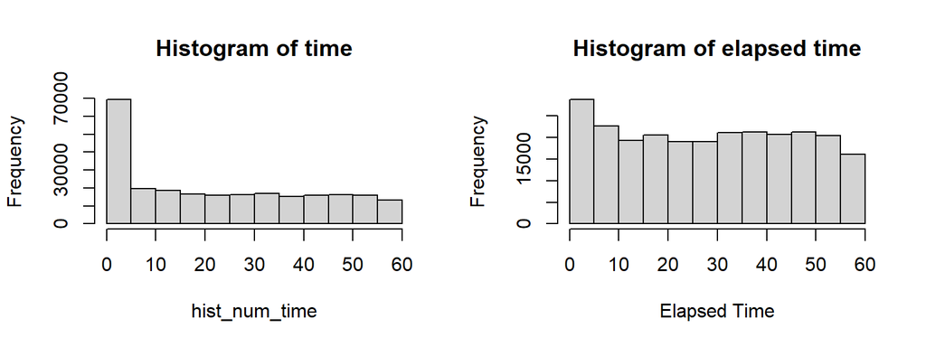

$time \sim Unif(a=0,b=60)$

$\text{elapsed time} \sim Unif(a=0,b=60)$

The peak at 0 seems to be an error. We replace the null values with a uniform distribution from 0 to 60,

#### `stage_data$age`

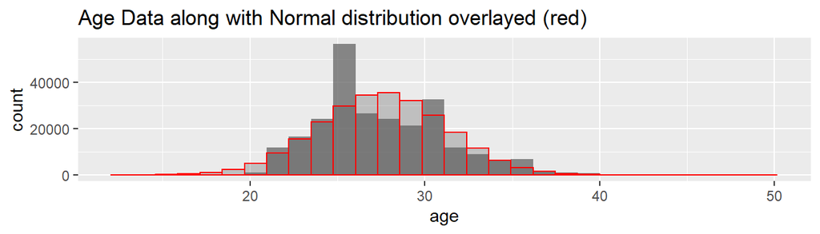

$N(\mu_{age}, \sigma_{age}) \sim \text{Age Data}$

Null-values replaced by above distribution.

#### `stage_data$team`

`NA` or `""` $\implies$ *“No Team”*

Replaced the *empty characters* and *null-values* with *“No Team”*.

#### `stage_data$points`

Removing the column due to number of null values.

#### `stage_data$bib_number`

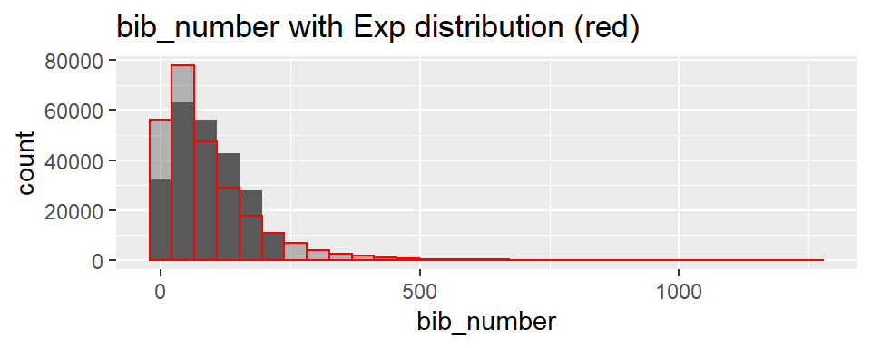

bib_number $\sim Exp(rate=\dfrac{1}{\mu_{\text{bib_number}}})$

Replacing *null-values* with the values following the above distribution.

```
##   edition year stage_results_id rank time rider age team elapsed bib_number
## 1       0    0                0    0    0     0   0    0       0          0
```

`tdf_winners`

Columns consisting of null values:

```
##   edition start_date winner_name winner_team distance time_overall time_margin
## 1       0          0           0           0        0            8           8
##   stage_wins stages_led height weight age born died full_name nickname
## 1          0          0     40     39   0    0   50        60       32
##   birth_town birth_country nationality
## 1          0             0           0
```

#### `tdf_winners$height` & `tdf_winners$weight`

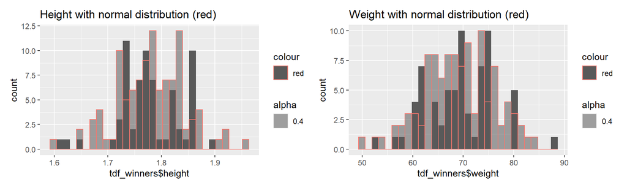

Height, Weight $\sim N(\mu_{Height,Weight},\sigma_{Height,Weight})$

Replaced null values with the normally distributed random variables with height’s and weight’s $\mu$s and $\sigma$s.

#### Removing `nickname`,`full_name`,`died` columns as they are not useful for analysis.

#### `tdf_winners$time_overall` & `tdf_winners$time_margin`

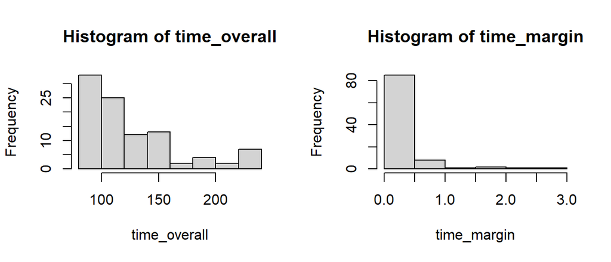

Substituting *null-values* with exponentially distributed random variables since they both approximately follow exponential distributions.

All three data-sets now have no-null values.

Adding new columns will be included in the *Analysis section* for calculating and analyzing new information.

### Analysis

The table below shows a data extracted from tdf_winners, which contains data about the winners in the most prestigious and difficult cycle racing event. It contains data such as winners name, age, weight, height, birth country along with these, some new columns have been added such as Average Velocity calculated using distance covered in overall time by the rider, BMI (Body mass index) has been calculated using the weight and height of rider.

Tour de France winners table

| Winner_name | Average_velocity | Weight | Height | BMI | Age | Nationality |
| --- | --- | --- | --- | --- | --- | --- |
| Maurice Garin | 1.540709 | 60.00000 | 1.620000 | 22.86237 | 32 | Italy |
| Henri Cornet | 1.515943 | 72.65036 | 1.705735 | 24.96979 | 19 | France |
| Louis Trousselier | 2.188419 | 82.59391 | 1.777542 | 26.14017 | 24 | France |
| RenÃ© Pottier | 1.399015 | 70.31117 | 1.754120 | 22.85102 | 27 | France |
| Lucien Petit-Breton | 1.300772 | 70.03112 | 1.667166 | 25.19610 | 24 | France |
| Lucien Petit-Breton | 3.287014 | 62.93428 | 1.826284 | 18.86908 | 25 | France |

Now, for analysis and future predictions for people interested in the field of sport competition which depends on physical fitness. Firstly, checking whether the genetics traits such as the birth country has any effects on the performance compared to others. To see genetic effects on performance we can visualize the winners birth country in the tfd_winners data.

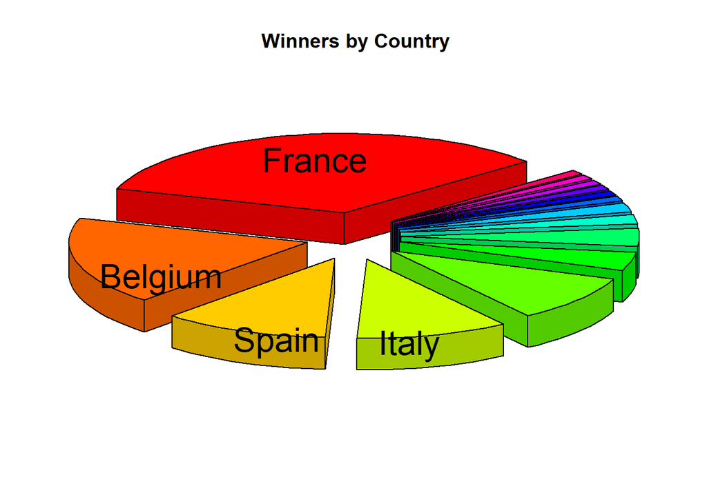

Figure 1: Pie chart for Winner’s countries

Winners by Country table

| Country | N_winners | Percentage |
| --- | --- | --- |
| France | 36 | 33.962264 |
| Belgium | 19 | 17.924528 |
| Spain | 12 | 11.320755 |
| Italy | 11 | 10.377358 |
| USA | 10 | 9.433962 |
| Kenya | 4 | 3.773585 |

It’s pretty clear that France has dominated in the event. French riders has won the event 36 times, which equals 33.96% hit ratio, followed by Belgium with 19 times. Germany, Ireland, Wales stands last with only 1 win in the event so far i.e 0.94% hit ratio. Also, with time the distance covered by riders have decreased which has made the event easier for today’s riders compared to the ones participated two decades ago! But with distance has average velocity of riders increased? If yes, then does it has any relations with BMI and likely being leaner overall.

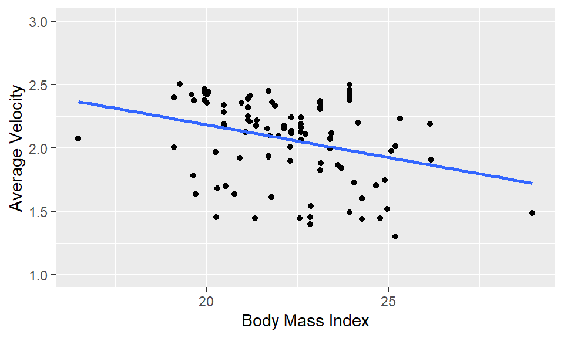

Figure 2: The relation between BMI and Average Velocity

Well on seeing the plot, it’s clearly evident that as the BMI increase the average velocity of the riders decreases. But in-spite of the trend it is more interesting to know why this trend occur. Considering the fact France is a hilly regions and from past few events the number of mountain stages are increased due to which riders having low body fat percentage can have better overall performance with good power to weight ratio. It’s beneficial to conclude that lighter and leaner athletes will have greater chances of winning the event. In the Tour de France different age group of people participate, so is there any trend that certain age group is having a better overall performance? To check the trend we can group the athletes in three age groups 18-24, 25-30. 30-40. For visualization we can use the age of winner and average velocity to see overall performance.

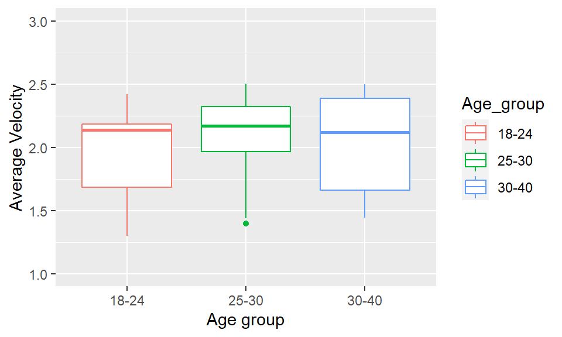

Figure 3: The relation between Age groups and Average Velocity

### Conclusions

2. Does an athlete’s BMI influence their speed?

Yes, the athlete’s BMI does influence speed. From the graph we can clearly see the relationship between body mass index and average velocity is a linear relationship with a negative slope. Considering the BMI outliers (16 & 29) we are still confident concluding that athletes with a lower BMI are faster.

3. Is there an age group that performs best?

This is interesting as there is a small range of winner’s ages 19-36. The median age of a winner is 28. This coincides with our findings relating to speed. We created three age categories 18-24, 25-30 and 30-40. We can see from the graph that the 25-30 category raced with a higher average speed than the other groups. So, some experience is good, but the athletes will most likely hit their speed peak in their late 20s.